# A note for multiple plots

surecalois

10/18/2020

# make some simple plots

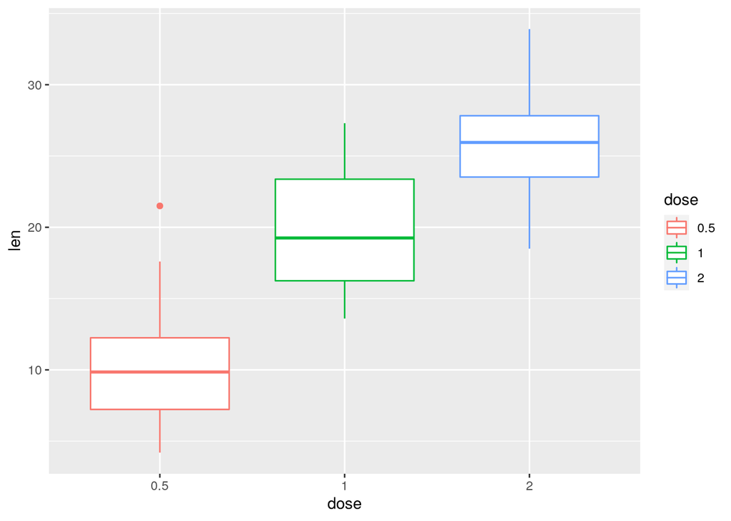

```r
data("ToothGrowth")
ToothGrowth$dose = factor(ToothGrowth$dose)
bxp = ggplot(data = ToothGrowth) + geom_boxplot(aes(x = dose, y = len,color = dose))
print(bxp)
```

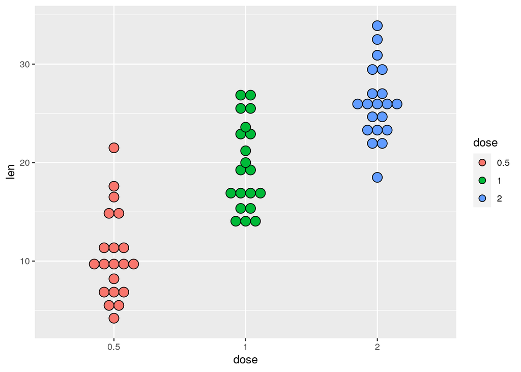

```r
dp = ggplot(data = ToothGrowth) +
          geom_dotplot(aes(x = dose, y = len,fill = dose),
            binwidth = 1,
            binaxis = "y",
            stackdir = "center"
          )
print(dp)
```

## the sorting problem

this plot require some setting. the x-axis is names. but order need to be assigned to them. function “order” can be used first order by cyl, then mpg. And cyl and mpg should have orders already. if not, assigned something to them.“fct_rev” can be used to reverse a factor order.

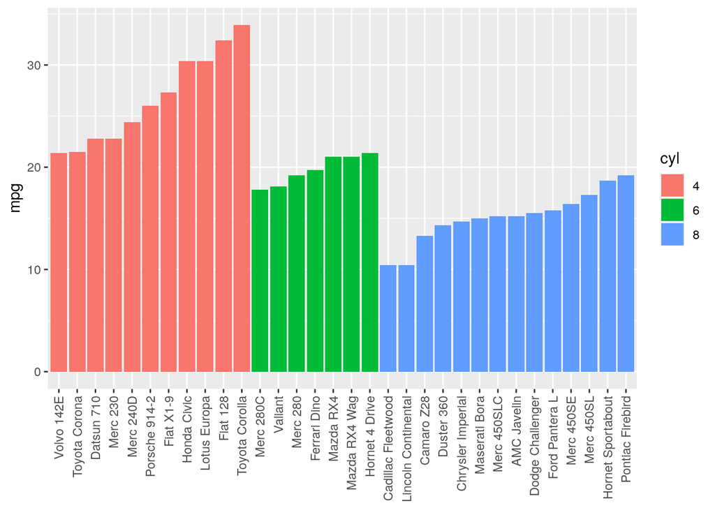

```r
data("mtcars")
mtcars$name = rownames(mtcars)
mtcars$cyl = factor(mtcars$cyl)
mtcars$name = with(mtcars,factor(name,levels = name[order(cyl,mpg)]))

bp <- ggplot(data = mtcars) + geom_bar(aes(x = name,y = mpg,fill = cyl,group = cyl),stat = "identity")+
  theme(axis.text.x = element_text(angle = 90, vjust = 0.5, hjust=1),axis.title.x = element_blank())
print(bp)
```

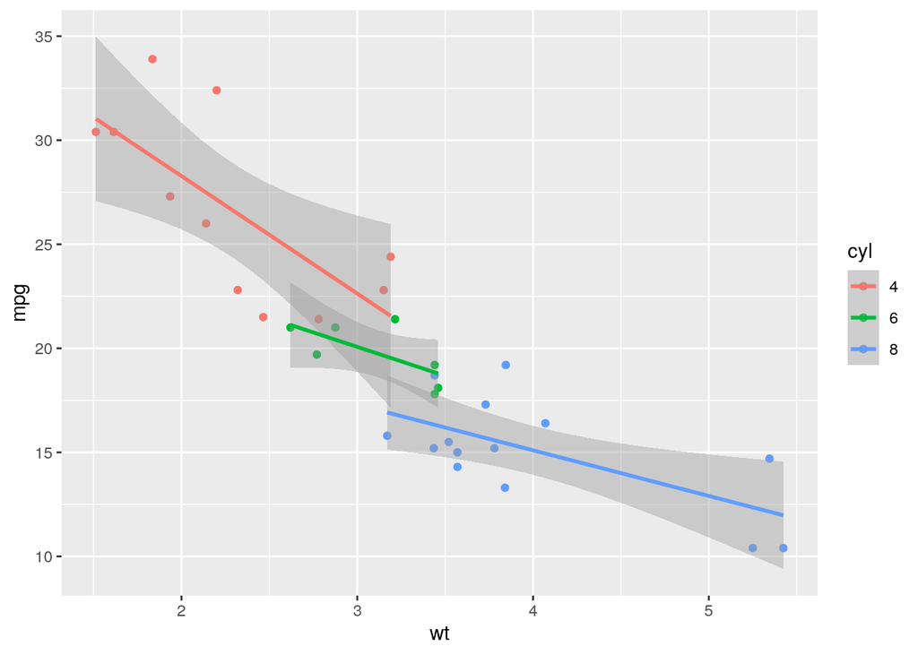

```r
sp <- ggplot(data = mtcars) + geom_point(aes(x = wt,y = mpg,color = cyl,group = cyl)) +
                              geom_smooth(aes(x = wt,y = mpg,color = cyl,group = cyl),
                                          formula = 'y ~ x',
                                          method=lm, se=TRUE)
print(sp)
```

## layout multiple plots

now begin the layout things. let’s begin with some simple things.

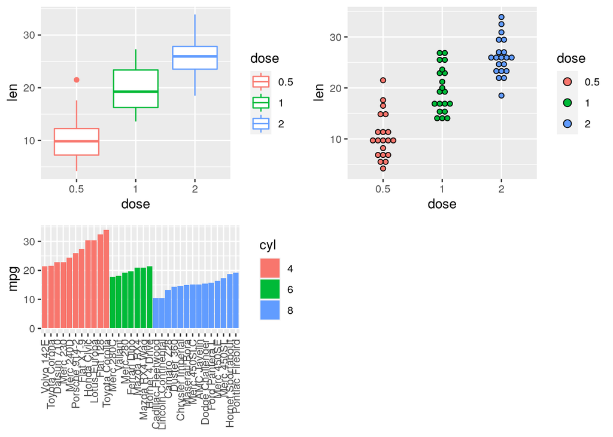

```r
#too simple, not align at all
grid.arrange(bxp, dp, bp,
             ncol = 2, nrow = 2)
```

another way to do it, but stretch one plot to cover the whole column

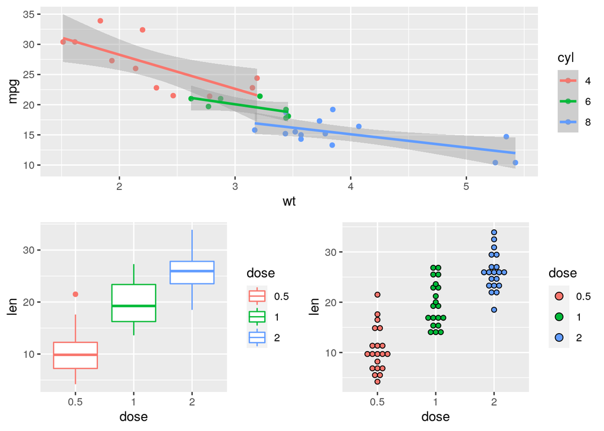

```r
#the right hand side is not align
grid.arrange(sp,arrangeGrob(bxp, dp, ncol = 2),nrow = 2)
```

now try the matrix layout, similar to css grid. It seems the panels are aligned on both end.

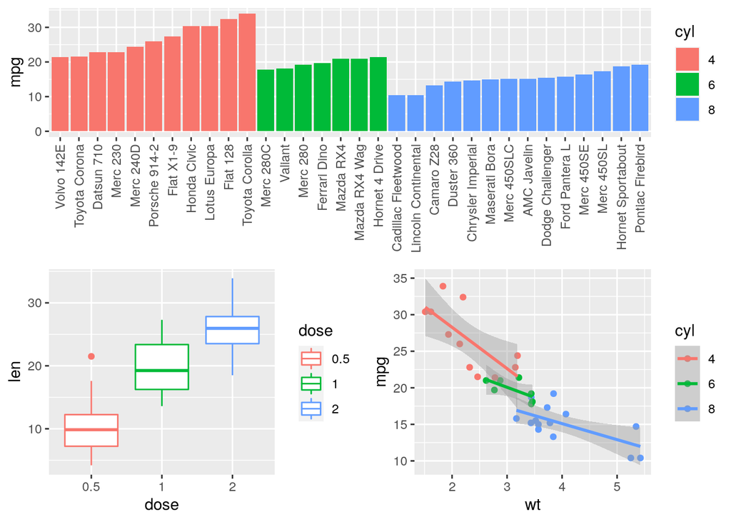

```r
grid.arrange(bp,bxp, sp,
             ncol = 2, nrow = 2,
             layout_matrix = rbind(c(1,1), c(2,3)))
```

try to use the pure gtalbe methods. make some plots, and display them with grid.arrange from gridExtra. to do that properly, you need to control figure width and height. default is 7 and 5.

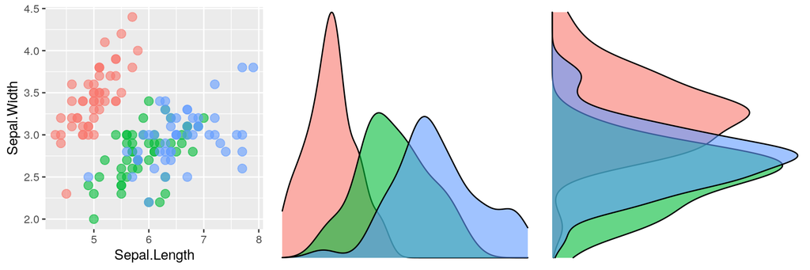

```r
#default width = 7, height = 5
data("iris")

sp <- ggplot(data = iris)+
              geom_point(aes(x = Sepal.Length, y = Sepal.Width,color = Species),size = 3, alpha = 0.6)+
                theme(legend.position = "none")

xplot <- ggplot(data = iris)+
              geom_density(aes(x = Sepal.Length,fill = Species),alpha = 0.6) +
                theme_void() +
                theme(legend.position = "none")

yplot <- ggplot(data = iris)+
              geom_density(aes(x = Sepal.Width,fill = Species),alpha = 0.6) +
                theme_void() +
                theme(legend.position = "none") + coord_flip()

grid.arrange(sp,xplot, yplot,ncol = 3,nrow= 1)
```

make some gtables with ggplotGrob. and combine them with rbind and cbind. the matrix way is for whole plots, do not align the panel. rbind, cbind, seems work fine with panel.

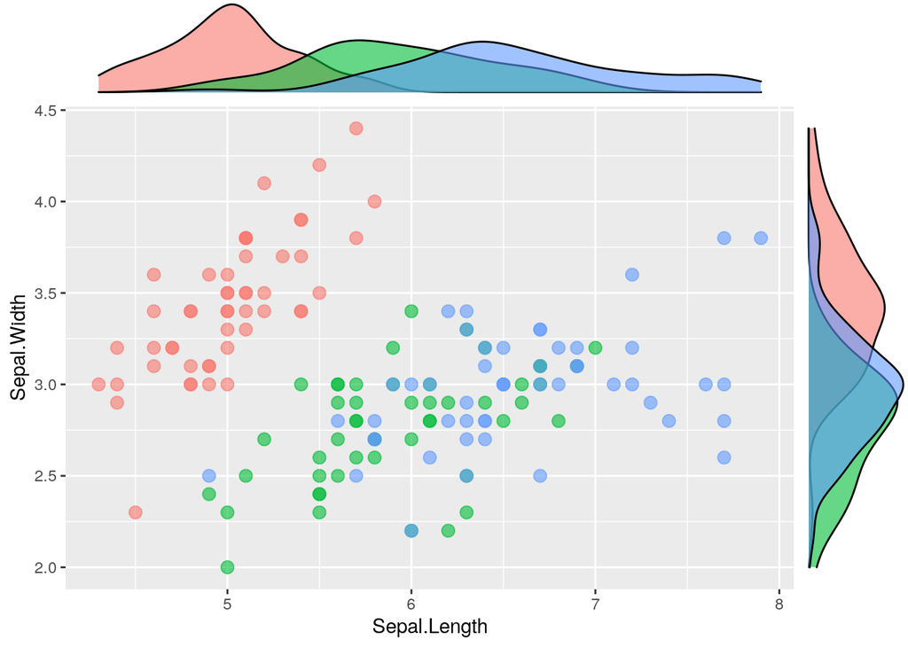

```r
asp = 7/5
gsp = ggplotGrob(sp)
gxplot = ggplotGrob(xplot)
gyplot = ggplotGrob(yplot)
empty = ggplotGrob(ggplot(data.frame()) + geom_point()+theme_void())


a = gtable_rbind(gxplot,gsp)
b = gtable_rbind(empty,gyplot)

c = gtable_cbind(a,b)
c$heights[7] = 0.2*c$heights[7]
c$widths[14] = 0.2/asp*c$widths[14]

grid.newpage()
grid.draw(c)
```

## multiple pages

for facet_warp and the last page is different and you need to insert things to make them look similar.

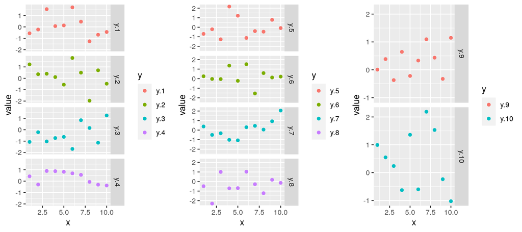

```r
set.seed(123)
n = 10
data = data.frame(x = 1:n)
for(i in 1:10){
  data = cbind(data,rnorm(10))
}
names(data) = c("x",paste("y",1:n,sep = "."))

pdata = gather(data,key = "y",value = "value", starts_with("y"))
pdata$y = factor(pdata$y,levels = unique(pdata$y),ordered = F)
w = list(
  c("y.1","y.2","y.3","y.4"),
  c("y.5","y.6","y.7","y.8"),
  c("y.9","y.10","y.11")
)
pl = list()
for(i in 1:3){
  p = ggplot(data = pdata %>% filter(y %in% w[[i]])) + geom_point(aes(x = x, y = value,color = y))
  pl[[i]] = p + facet_wrap(~y,ncol = 1,strip.position = "right")
}

ml <- marrangeGrob(pl, nrow=1, ncol=1,top = NULL)

grid.arrange(ml[[1]],ml[[2]],ml[[3]],ncol = 3)
```

deal with the last page by inserting things, and the axis is the 5.5pt thing

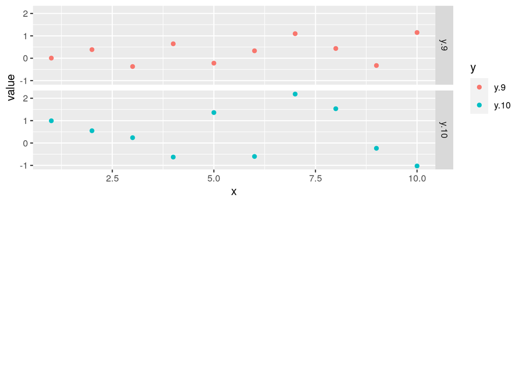

```r
ml[[3]]$grobs[[1]] -> s

s = gtable_add_rows(s,unit(2,"null"))
ep = dim(s)[1]
s = gtable_add_grob(s,zeroGrob(),ep,1)
#s$heights[ep] = unit(2,"null")

s = gtable_add_rows(s,unit(2*5.5,"pt"))
ep = dim(s)[1]
s = gtable_add_grob(s,zeroGrob(),ep,1)
#s$heights[ep] = unit(2*5.5,"pt")

grid.newpage()
grid.draw(s)
```

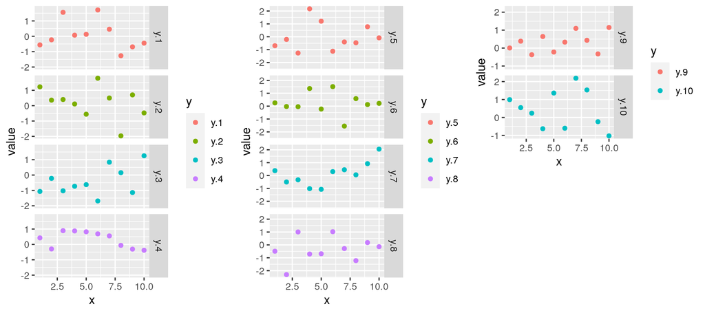

```r
grid.arrange(ml[[1]],ml[[2]],s,ncol = 3)
```

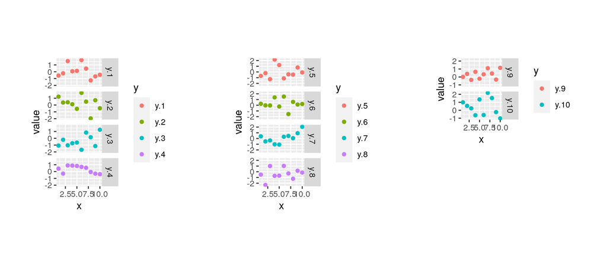

```r
ml[[3]]$grobs[[1]] = s

pml = lapply(ml, function(x) gtable_add_padding(x,unit(c(2,1,2,1),rep("cm",4))))
class(pml)=class(ml)
#ggsave("multipage.pdf", pml,width =210, height = 297, units = "mm")
grid.arrange(pml[[1]],pml[[2]],pml[[3]],ncol = 3)
```

## other things

extract the legend. it is called guide-box

```r
g_legend <- function(a.gplot){
  tmp <- ggplot_gtable(ggplot_build(a.gplot))
  leg <- which(sapply(tmp$grobs, function(x) x$name) == "guide-box")
  legend <- tmp$grobs[[leg]]
  legend
}
```